# Week 6 - RMarkdown Homework

Keanu Rochette-Yu Tsuen

2024-10-03

## Introduction - Taking a shot at using RMarkdown

*Disclaimer: this assignment will be (a little) chaotic. Enjoy!*

Howdy y’all, today we’ll create my first markdown document (*+ output* ).  
Not gonna lie this one was a tough one, the table in particular was giving me a hard time.  
But in the words of Sia:

> “I’m unstoppable. I’m a Porsche with no breaks.”  
> *Sia, somewhere cool*

## Load the Libraries

To start and *slay* that code, we are loading them libraries.

```r
library(tidyverse) #to keep things organized
library(here) # so our pathways are unbreakable
library(gt) # tables baby!
library(ghibli) # for the pretty colors
```

## Load the Data

We need something to work with.  
We’ll use data collected by the Silbiger Lab ( *yas!* ).

```r
chem_data<- read_csv(here("Week_04", "data", "chemicaldata_maunalua.csv"))
# gotta use read_csv instead of read.csv, more demure
```

## Making a Summary Table

To show off those coding skills, we’ll make a “simple” summary table. ( *he thought…* )

```r
chem_data %>%
    # remove those NA gurl! bad vibes
  drop_na() %>%
    # Swith her up so she's longer
  pivot_longer (cols = Temp_in:percent_sgd,
                names_to = "Parameter",
                values_to = "Values") %>%
    # I don't need those either
  select(-Site, -Season, -Tide_time, -Waypoint) %>%
    # cluster the data by zone and by parameter
  group_by(Zone, Parameter) %>%
    # then we can get our little summary
  summarize(Mean = mean(Values), Median = median(Values),
            StandDev= sd(Values)) %>%
    # we'll round those values #cutesy
  mutate_if(is.numeric, round,digits = 2) %>%
    # Problems start here: we need a wide boi for this task
    # We also need the columns with names as ZONE_VALUE,
    # hence why I used the names_glue function
  pivot_wider(names_from = "Zone",
              values_from = c(Mean:StandDev),
              names_glue = "{Zone}_{.value}") %>%
    # I needed to rearrange my columns so all the summaries are by "Zones".
    # But ya boi doesn't know any other way to do it.
    # So I just had to type it by hand. Send help please...
  select(Parameter,
         Ambient_Mean, Ambient_Median, Ambient_StandDev,
         Diffuse_Mean, Diffuse_Median, Diffuse_StandDev,
         Offshore_Mean, Offshore_Median, Offshore_StandDev,
         Transition_Mean, Transition_Median, Transition_StandDev) %>%
    # Anyway, then we can set the biogeochem parameters as the row names.
  gt(rowname_col = "Parameter") %>%
    # Gotta keep it nice and tidy with a title and subtitle
  tab_header(title = "Summary Statistics of Biogeochemical Parameters",
             subtitle= "Taken in Maunalua Bay")  %>%
    # All that hard work for the grand finalé.
    # We are creating over arching column categories,
    # representing the sampled zones, under which the summary statistics
    # will be nicely grouped.
  tab_spanner_delim(delim = "_")
```

Summary Statistics of Biogeochemical Parameters

Taken in Maunalua Bay

|  | Ambient Mean | Ambient Median | Ambient StandDev | Diffuse Mean | Diffuse Median | Diffuse StandDev | Offshore Mean | Offshore Median | Offshore StandDev | Transition Mean | Transition Median | Transition StandDev |
| --- | --- | --- | --- | --- | --- | --- | --- | --- | --- | --- | --- | --- |
| NN | 0.28 | 0.14 | 0.94 | 1.55 | 0.36 | 2.77 | 0.12 | 0.10 | 0.04 | 4.18 | 1.38 | 6.32 |
| Phosphate | 0.12 | 0.11 | 0.04 | 0.16 | 0.12 | 0.09 | 0.16 | 0.16 | 0.03 | 0.25 | 0.19 | 0.18 |
| Salinity | 34.59 | 34.61 | 0.16 | 34.09 | 34.46 | 0.93 | 34.61 | 34.61 | 0.01 | 33.09 | 33.86 | 1.95 |
| Silicate | 2.41 | 1.87 | 3.88 | 14.38 | 5.04 | 21.54 | 1.72 | 1.62 | 0.31 | 37.50 | 20.40 | 44.75 |
| TA | 2256.51 | 2259.75 | 32.52 | 2263.86 | 2263.40 | 39.84 | 2276.19 | 2276.49 | 12.03 | 2264.55 | 2263.49 | 52.72 |
| Temp_in | 25.73 | 25.80 | 1.24 | 25.53 | 25.65 | 1.35 | 24.39 | 24.43 | 0.21 | 25.38 | 25.33 | 1.46 |
| pH | 8.04 | 8.02 | 0.08 | 8.04 | 8.00 | 0.10 | 7.99 | 7.98 | 0.04 | 8.04 | 8.01 | 0.11 |
| percent_sgd | 0.31 | 0.24 | 0.49 | 1.83 | 0.65 | 2.76 | 0.22 | 0.21 | 0.04 | 4.79 | 2.58 | 5.74 |

Look at that beautiful table !

> “Very Mindful! Very Demure!  
> *Joolie Lebron, Tiktok (I think)*

## Making a Pretty Graph

K! Now that the table is done, we can try to make a graph with ggplot.  
There are many options here.

- time series *(actually no, we don’t have any dates. LOL! )*
- box plots
- linear regressions

But today, I decide to be wild and make violin plots.

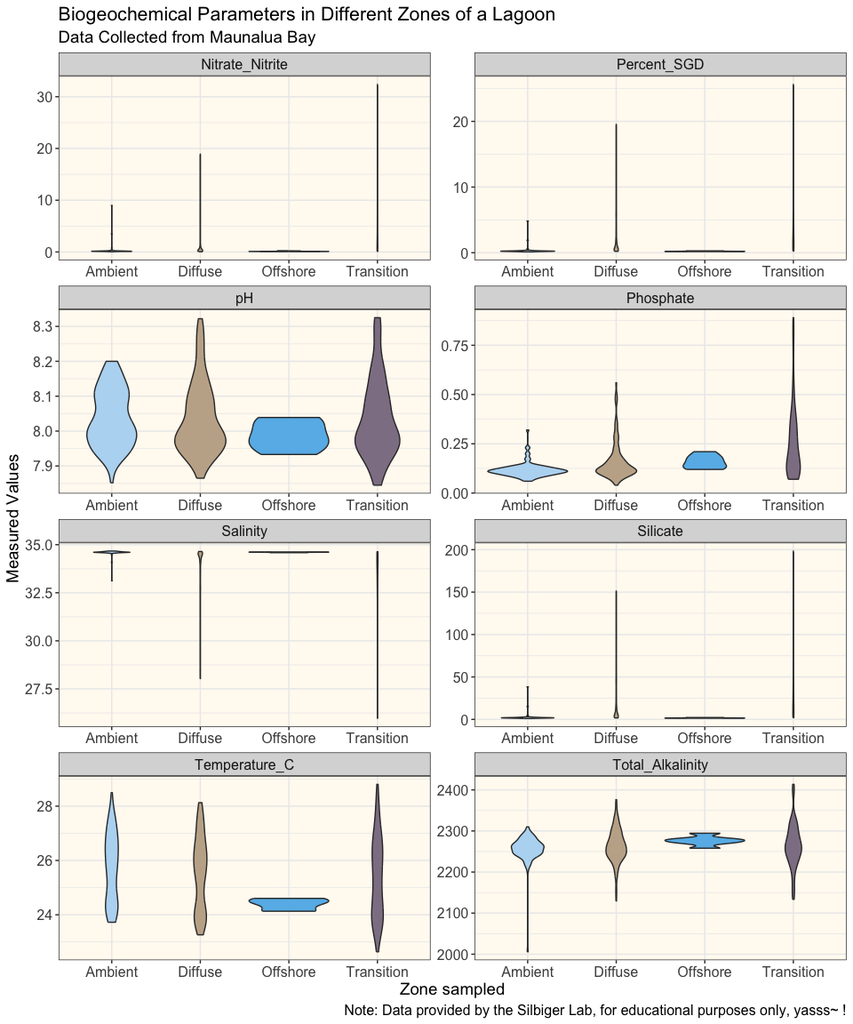

```r
chem_data %>%
    # again, run away from problems, run away from NAs.
  drop_na() %>%
    # Idk, the names weren't my vibe so I changed them
  rename(Nitrate_Nitrite = NN,  Percent_SGD= percent_sgd,
         Total_Alkalinity = TA, Temperature_C= Temp_in) %>%
    # Long boiiiii
  pivot_longer (cols = Temperature_C:Percent_SGD,
                names_to = "Parameter",
                values_to = "Values") %>%
    # I didn't need those so ... gurl bye!
  select(-Site, -Season, -Tide_time, -Waypoint) %>%
    # now the fun part, ggplot !
  ggplot(aes(x= Zone, y = Values, fill = Zone)) +
    # make them violin plots
  geom_violin() +
    # we be wild but tidy, everything in 2 columns only.
    # and also each graph gets their own scale, bcs idk... equity?
  facet_wrap(~Parameter, ncol = 2, scales= "free") +
    # graph needs to be clear, labels, labels, labels
  labs(title = "Biogeochemical Parameters in Different Zones of a Lagoon",
       subtitle = "Data Collected from Maunalua Bay",
       x = "Zone sampled",
       y = "Measured Values", #give pretty names to the plot and axes
       fill = "Zones",
       caption = "Note: Data provided by the Silbiger Lab, for educational purposes only, yasss~ !") +
    # we need something basic to balance it out: theme_bw()
  theme_bw() +
    # yas-ifying that graph with some font size change and a background color
  theme(plot.title = element_text(size=16),
        plot.subtitle = element_text(size=14),
        axis.title = element_text(size = 14),
        axis.text = element_text(size = 12),
        strip.text.x = element_text(size = 12),
        plot.caption = element_text(size = 12),
        panel.background = element_rect(fill = "#FFFAF1"),
        legend.position = "none") + # no need legend, redundant here
    # yas-ifying her even more with some ghibli theme colors
  scale_fill_ghibli_d("SpiritedMedium", direction = -1)
```

## Closing remarks

Thanks for reading til here!  
Hope that was entertaining and not too cringey.  
*Maybe a bit cringey tho hihi!*